# Notebook

## Week 3B: Geospatial Data Analysis and GeoPandas

Sep 22, 2021

## Housekeeping

- [Homework #2](https://github.com/MUSA-550-Fall-2021/assignment-2) due a week from today (9/29)
- Choose a dataset to visualize and explore
  - [OpenDataPhilly](https://opendataphilly.org) or one your choosing
  - Email me if you want to analyze one that's not on OpenDataPhilly

## Agenda for Week #3

**Last lecture**

- Vector data and introduction to GeoPandas
- Spatial relationships and joins
- Visualization for geospatial data

**Today**

- Demo: 311 requests by neighborhood in Philadelphia (continued)
- Exercise: Property assessments by neighborhood

```python
# Let's setup the imports we'll need first
import numpy as np
from matplotlib import pyplot as plt
import pandas as pd
import geopandas as gpd
```

## Last time: 311 requests in 2020

Load 311 requests in Philadelphia from the `data/` directory.

Source: [OpenDataPhilly](https://www.opendataphilly.org/dataset/311-service-and-information-requests)

```python
# Load the data from a CSV file into a pandas DataFrame
requests = pd.read_csv('./data/public_cases_fc_2020.csv.tar.gz')
```

```python
print("number of requests = ", len(requests))
```

```
number of requests =  727746
```

```python
requests.head()
```

|  | objectid | service_request_id | status | status_notes | service_name | service_code | agency_responsible | service_notice | requested_datetime | updated_datetime | expected_datetime | address | zipcode | media_url | lat | lon |
| --- | --- | --- | --- | --- | --- | --- | --- | --- | --- | --- | --- | --- | --- | --- | --- | --- |
| 0 | 7890359 | 13127945 | Closed | Question Answered | Information Request | SR-IR01 | Police Department | NaN | 2020-02-05 11:00:11 | 2020-02-05 11:00:23 | 2020-02-05 11:30:20 | NaN | NaN | NaN | NaN | NaN |
| 1 | 9551814 | 13788036 | Closed | Question Answered | Information Request | SR-IR01 | State/Federal Government Offices | NaN | 2020-11-24 11:34:27 | 2020-11-24 11:34:32 | 2020-11-24 12:00:24 | NaN | NaN | NaN | NaN | NaN |
| 2 | 8138665 | 13251716 | Closed | NaN | Information Request | SR-IR01 | License & Inspections | NaN | 2020-03-26 11:40:36 | 2020-03-26 11:40:47 | 2020-03-26 12:00:21 | NaN | NaN | NaN | NaN | NaN |
| 3 | 8433329 | 13376073 | Closed | NaN | Information Request | SR-IR01 | License & Inspections | NaN | 2020-05-22 12:00:10 | 2020-05-22 12:00:39 | 2020-05-22 12:30:22 | NaN | NaN | NaN | NaN | NaN |
| 4 | 8433331 | 13376078 | Closed | NaN | Information Request | SR-IR01 | Streets Department | NaN | 2020-05-22 12:00:44 | 2020-05-22 12:00:53 | 2020-05-22 12:30:22 | NaN | NaN | NaN | NaN | NaN |

## First, convert to a GeoDataFrame

Remove the requests missing lat/lon coordinates

```python
requests = requests.dropna(subset=['lat', 'lon'])
```

Create Point objects for each `lat` and `lon` combination.

We can use the helper utility function: [`geopandas.points_from_xy()`](https://geopandas.org/reference/geopandas.points_from_xy.html#geopandas.points_from_xy)

```python
requests['Coordinates'] = gpd.points_from_xy(requests['lon'], requests['lat'])
```

```python
requests['Coordinates'].head()
```

```
13    POINT (-75.16257 40.04816)
18    POINT (-75.18500 40.03733)
21    POINT (-75.20887 40.02665)
24    POINT (-75.10652 40.03439)
25    POINT (-75.16350 39.93616)
Name: Coordinates, dtype: geometry
```

Now, convert to a GeoDataFrame.

**Important**

- Don't forget to set the CRS manually!
- **The CRS you specify when creating a GeoDataFrame should tell geopandas what the coordinate system the input data is in.**
- Usually you will be reading lat/lng coordinates, and will need to specify the crs as EPSG code 4326
- You should specify the crs as a string using the syntax: `ESPG:4326`

Since we're only using a few EPSG codes in this course, you can usually tell what the CRS is by looking at the values in the Point() objects.

Philadelphia has a latitude of about 40 deg and longitude of about -75 deg.

Our data must be in the usual lat/lng EPSG=4326.

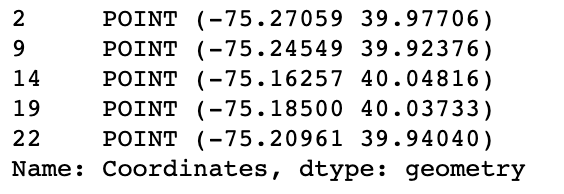

```python
requests = gpd.GeoDataFrame(requests,
                            geometry="Coordinates",
                            crs="EPSG:4326")
```

## Next, identify the top 20 most common requests

Group by the service name and calculate the size of each group:

```python
service_types = requests.groupby('service_name').size()
```

Sort by the number (in descending order):

```python
service_types = service_types.sort_values(ascending=False)
```

Slice the data to take the first 20 elements:

```python
top20 = service_types.iloc[:20]
top20
```

```
service_name
Rubbish/Recyclable Material Collection    47690
Illegal Dumping                           26252
Maintenance Complaint                     24722
Abandoned Vehicle                         24538
Information Request                       18480
Graffiti Removal                          16264
Street Light Outage                       13707
Street Defect                              9670
Agency Receivables                         6527
Other (Streets)                            5994
Construction Complaints                    5918
Sanitation / Dumpster Violation            5563
Fire Safety Complaint                      5276
Street Trees                               5141
LI Escalation                              4788
Maintenance Residential or Commercial      3389
Traffic Signal Emergency                   3013
Parks and Rec Safety and Maintenance       2773
License Complaint                          2593
Alley Light Outage                         2340
dtype: int64
```

## Let's trim to only the trash-related requests

```python
trash_requests = requests.loc[
    requests["service_name"] == "Rubbish/Recyclable Material Collection"
].copy()

print("The nuumber of trash-related requests = ", len(trash_requests))
```

```
The nuumber of trash-related requests =  47690
```

## Trash collection has been a **BIG** issue in Philadelphia recently

See for example, [this article](https://www.inquirer.com/news/philadephia-trash-recycling-collection-delays-covid-20200806.html) in the Philadelphia Inquirer

## Let's plot the monthly totals for 2020

```python
# Convert the requested datetime to a column of Datetime objects
trash_requests['requested_datetime'] = pd.to_datetime(trash_requests['requested_datetime'])

# Use the .dt attribute to extract out the month name
trash_requests['month'] = trash_requests['requested_datetime'].dt.month_name()
```

### Note: Setting with a copy warning

TL;DR: This is usually fine!

If you select a subset of a dataframe (a "slice") and then make changes (like adding a new column), you will get this warning. There is a good discussion of the issue on [StackOverflow](https://stackoverflow.com/questions/20625582/how-to-deal-with-settingwithcopywarning-in-pandas).

You can usually make this go away if you add a `.copy()` after you perform your selection. For example, this warning will go away if we had done:

```
trash_requests = requests.loc[requests["service_name"] == "Rubbish/Recyclable Material Collection"].copy()
```

```python
totals_by_month = trash_requests.groupby("month", as_index=False).size()

totals_by_month
```

|  | month | size |
| --- | --- | --- |
| 0 | April | 5778 |
| 1 | August | 4466 |
| 2 | December | 2757 |
| 3 | February | 2067 |
| 4 | January | 2710 |
| 5 | July | 9627 |
| 6 | June | 6485 |
| 7 | March | 2460 |
| 8 | May | 6572 |
| 9 | November | 1729 |
| 10 | October | 1335 |
| 11 | September | 1704 |

### Note: I've used the `as_index=False` syntax here

This will force the size() function to return a DataFrame instead of having the `month` column as the index of the resulted groupby operation.

It saves us from having to do the `.reset_index()` function call after running the `.size()` function.

## Plot a bar chart with seaborn

For making static bar charts with Python, seaborn's [`sns.barplot()`](https://seaborn.pydata.org/generated/seaborn.barplot.html) is the best option

```python
import seaborn as sns
```

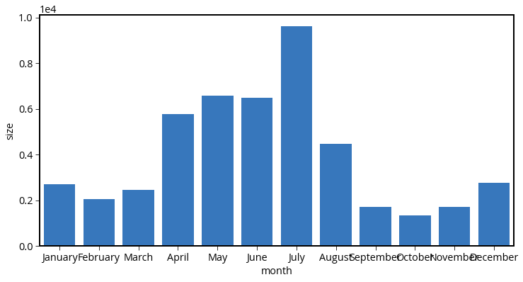

```python
# Initialize figure/axes
fig, ax = plt.subplots(figsize=(12, 6))

# Plot!
sns.barplot(
    x="month",
    y="size",
    data=totals_by_month,
    color="#2176d2",
    ax=ax,
    order=[
        "January",
        "February",
        "March",
        "April",
        "May",
        "June",
        "July",
        "August",
        "September",
        "October",
        "November",
        "December",
    ],
)
```

## Example: Improving the aesthetics of matplotlib

The trend is clear in the previous chart, but can we do a better job with the aesthetics? Yes!

For reference, here is a common way to clean up charts in matplotlib:

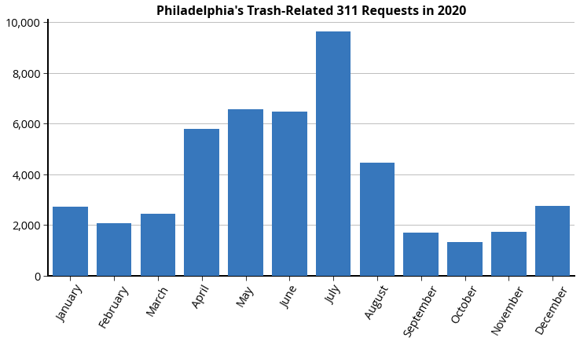

```python
# Initialize figure/axes
fig, ax = plt.subplots(figsize=(12, 6))

# Plot!
sns.barplot(
    x="month",
    y="size",
    data=totals_by_month,
    color="#2176d2",
    ax=ax,
    order=[
        "January",
        "February",
        "March",
        "April",
        "May",
        "June",
        "July",
        "August",
        "September",
        "October",
        "November",
        "December",
    ],
    zorder=999,  # Make sure the bar charts are on top of the grid
)

# Remove x/y axis labels
ax.set_xlabel("")
ax.set_ylabel("")

# Format the ytick labels to use a comma and no decimal places
ax.set_yticklabels([f"{yval:,.0f}" for yval in ax.get_yticks()])

# Rotate the xticks
plt.setp(ax.get_xticklabels(), rotation=60)


# Add a grid backgrou d
ax.grid(True, axis="y")

# Remove the top and right axes lines
ax.spines["top"].set_visible(False)
ax.spines["right"].set_visible(False)

# Add a title
ax.set_title(
    "Philadelphia's Trash-Related 311 Requests in 2020", weight="bold", fontsize=16
);
```

## Now let's look at some geospatial trends!

## Let's convert from lat/lng to Web Mercator

The original data has EPSG=4326. We'll convert to EPSG=3857.

```python
trash_requests = trash_requests.to_crs(epsg=3857)
```

```python
trash_requests.head()
```

|  | objectid | service_request_id | status | status_notes | service_name | service_code | agency_responsible | service_notice | requested_datetime | updated_datetime | expected_datetime | address | zipcode | media_url | lat | lon | Coordinates | month |
| --- | --- | --- | --- | --- | --- | --- | --- | --- | --- | --- | --- | --- | --- | --- | --- | --- | --- | --- |
| 24 | 8180042 | 13269656 | Closed | NaN | Rubbish/Recyclable Material Collection | SR-ST03 | Streets Department | 2 Business Days | 2020-04-02 19:22:24 | 2020-04-06 07:02:57 | 2020-04-06 20:00:00 | 624 FOULKROD ST | NaN | NaN | 40.034389 | -75.106518 | POINT (-8360819.322 4870940.907) | April |
| 25 | 8180043 | 13266979 | Closed | NaN | Rubbish/Recyclable Material Collection | SR-ST03 | Streets Department | 2 Business Days | 2020-04-02 08:40:53 | 2020-04-06 07:02:58 | 2020-04-05 20:00:00 | 1203 ELLSWORTH ST | NaN | NaN | 39.936164 | -75.163497 | POINT (-8367162.212 4856670.199) | April |
| 57 | 7744426 | 13066443 | Closed | NaN | Rubbish/Recyclable Material Collection | SR-ST03 | Streets Department | 2 Business Days | 2020-01-02 19:17:55 | 2020-01-04 05:46:06 | 2020-01-06 19:00:00 | 9054 WESLEYAN RD | NaN | NaN | 40.058737 | -75.018345 | POINT (-8351004.015 4874481.442) | January |
| 58 | 7744427 | 13066540 | Closed | NaN | Rubbish/Recyclable Material Collection | SR-ST03 | Streets Department | 2 Business Days | 2020-01-03 07:01:46 | 2020-01-04 05:46:07 | 2020-01-06 19:00:00 | 2784 WILLITS RD | NaN | NaN | 40.063658 | -75.022347 | POINT (-8351449.489 4875197.202) | January |
| 175 | 7801094 | 13089345 | Closed | NaN | Rubbish/Recyclable Material Collection | SR-ST03 | Streets Department | 2 Business Days | 2020-01-15 13:22:14 | 2020-01-16 14:03:29 | 2020-01-16 19:00:00 | 6137 LOCUST ST | NaN | NaN | 39.958186 | -75.244732 | POINT (-8376205.240 4859867.796) | January |

## Calculate statistics by Zillow neighborhood

A GeoJSON holding Zillow definitions for Philadelphia neighborhoods is available in the `data/` directory.

```python
zillow = gpd.read_file('data/zillow_neighborhoods.geojson')
zillow = zillow.to_crs(epsg=3857)
```

```python
zillow.head()
```

|  | ZillowName | geometry |
| --- | --- | --- |
| 0 | Academy Gardens | POLYGON ((-8348795.677 4875297.327, -8348355.9... |
| 1 | Airport | POLYGON ((-8370923.380 4850336.405, -8370799.2... |
| 2 | Allegheny West | POLYGON ((-8367432.106 4866417.820, -8367436.0... |
| 3 | Andorra | POLYGON ((-8373967.120 4875663.024, -8374106.1... |
| 4 | Aston Woodbridge | POLYGON ((-8349918.770 4873746.906, -8349919.8... |

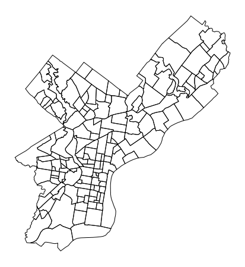

```python
fig, ax = plt.subplots(figsize=(8, 8))
ax = zillow.plot(ax=ax, facecolor='none', edgecolor='black')
ax.set_axis_off()
ax.set_aspect("equal")
```

### Goal: for each neighborhood, calculate the number of trash-related requests

Use the `sjoin()` function to match point data (requests) to polygon data (neighborhoods)

```python
joined = gpd.sjoin(trash_requests, zillow, op='within', how='left')
```

```python
joined.head()
```

|  | objectid | service_request_id | status | status_notes | service_name | service_code | agency_responsible | service_notice | requested_datetime | updated_datetime | expected_datetime | address | zipcode | media_url | lat | lon | Coordinates | month | index_right | ZillowName |
| --- | --- | --- | --- | --- | --- | --- | --- | --- | --- | --- | --- | --- | --- | --- | --- | --- | --- | --- | --- | --- |
| 24 | 8180042 | 13269656 | Closed | NaN | Rubbish/Recyclable Material Collection | SR-ST03 | Streets Department | 2 Business Days | 2020-04-02 19:22:24 | 2020-04-06 07:02:57 | 2020-04-06 20:00:00 | 624 FOULKROD ST | NaN | NaN | 40.034389 | -75.106518 | POINT (-8360819.322 4870940.907) | April | 70.0 | Lawndale |
| 25 | 8180043 | 13266979 | Closed | NaN | Rubbish/Recyclable Material Collection | SR-ST03 | Streets Department | 2 Business Days | 2020-04-02 08:40:53 | 2020-04-06 07:02:58 | 2020-04-05 20:00:00 | 1203 ELLSWORTH ST | NaN | NaN | 39.936164 | -75.163497 | POINT (-8367162.212 4856670.199) | April | 105.0 | Passyunk Square |
| 57 | 7744426 | 13066443 | Closed | NaN | Rubbish/Recyclable Material Collection | SR-ST03 | Streets Department | 2 Business Days | 2020-01-02 19:17:55 | 2020-01-04 05:46:06 | 2020-01-06 19:00:00 | 9054 WESLEYAN RD | NaN | NaN | 40.058737 | -75.018345 | POINT (-8351004.015 4874481.442) | January | 109.0 | Pennypack Woods |
| 58 | 7744427 | 13066540 | Closed | NaN | Rubbish/Recyclable Material Collection | SR-ST03 | Streets Department | 2 Business Days | 2020-01-03 07:01:46 | 2020-01-04 05:46:07 | 2020-01-06 19:00:00 | 2784 WILLITS RD | NaN | NaN | 40.063658 | -75.022347 | POINT (-8351449.489 4875197.202) | January | 107.0 | Pennypack |
| 175 | 7801094 | 13089345 | Closed | NaN | Rubbish/Recyclable Material Collection | SR-ST03 | Streets Department | 2 Business Days | 2020-01-15 13:22:14 | 2020-01-16 14:03:29 | 2020-01-16 19:00:00 | 6137 LOCUST ST | NaN | NaN | 39.958186 | -75.244732 | POINT (-8376205.240 4859867.796) | January | 21.0 | Cobbs Creek |

Note that this operation can be **slow**

Group by neighborhood and calculate the size:

```python
totals = joined.groupby('ZillowName', as_index=False).size()
type(totals)
```

```
pandas.core.frame.DataFrame
```

**Note:** we're once again using the `as_index=False` to ensure the result of the `.size()` function is a DataFrame rather than a Series with the `ZillowName` as its index

```python
totals.head()
```

|  | ZillowName | size |
| --- | --- | --- |
| 0 | Academy Gardens | 84 |
| 1 | Allegheny West | 330 |
| 2 | Andorra | 83 |
| 3 | Aston Woodbridge | 110 |
| 4 | Bartram Village | 35 |

Lastly, merge Zillow geometries (GeoDataFrame) with the total # of requests per neighborhood (DataFrame).

**Important**

When merging a GeoDataFrame (spatial) and DataFrame (non-spatial), you should always call the `.merge()` function of the spatial data set to ensure that the merged data is a GeoDataFrame.

For example...

```python
totals = zillow.merge(totals, on='ZillowName')
```

```python
totals.head()
```

|  | ZillowName | geometry | size |
| --- | --- | --- | --- |
| 0 | Academy Gardens | POLYGON ((-8348795.677 4875297.327, -8348355.9... | 84 |
| 1 | Allegheny West | POLYGON ((-8367432.106 4866417.820, -8367436.0... | 330 |
| 2 | Andorra | POLYGON ((-8373967.120 4875663.024, -8374106.1... | 83 |
| 3 | Aston Woodbridge | POLYGON ((-8349918.770 4873746.906, -8349919.8... | 110 |
| 4 | Bartram Village | POLYGON ((-8372041.314 4856283.292, -8372041.6... | 35 |

## Visualize as a choropleth map

Choropleth maps color polygon regions according to the values of a specific data attribute. *They are built-in to GeoDataFrame objects*.

First, plot the total number of requests per neighborhood.

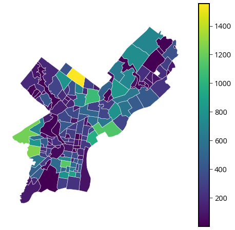

```python
# Create the figure/axes
fig, ax = plt.subplots(figsize=(8, 8))

# Plot
totals.plot(
    ax=ax,
    column="size",
    edgecolor="white",
    linewidth=0.5,
    legend=True,
    cmap="viridis"
)

# Format
ax.set_axis_off()
ax.set_aspect("equal")
```

## Can we make the aesthetics better?

## Yes!

- Make the colorbar line up with the axes. The default configuration will always overshoot the axes.
- Explicitly set the limits of the x-axis and y-axis to zoom in and center the map

```python
# Needed to line up the colorbar properly
from mpl_toolkits.axes_grid1 import make_axes_locatable
```

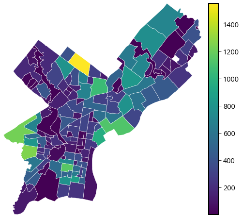

```python
# Create the figure
fig, ax = plt.subplots(figsize=(8, 8))

# NEW: Create a nice, lined up colorbar axes (called "cax" here)
divider = make_axes_locatable(ax)
cax = divider.append_axes("right", size="5%", pad=0.2)

# Plot
totals.plot(
    ax=ax,
    cax=cax,
    column="size",
    edgecolor="white",
    linewidth=0.5,
    legend=True,
    cmap="viridis",
)

# NEW: Get the limits of the GeoDataFrame
xmin, ymin, xmax, ymax = totals.total_bounds

# NEW: Set the xlims and ylims
ax.set_xlim(xmin, xmax)
ax.set_ylim(ymin, ymax)

# Format
ax.set_axis_off()
ax.set_aspect("equal")
```

These improvements are optional, but they definitely make for nicer plots!

## Can we classify the data into bins?

Yes, built-in to the `plot()` function!

## Classification schemes

Many different schemes, but here are some of the most common ones:

1. "Quantiles" : assigns the same number of data points per bin
2. "EqualInterval" : divides the *range of the data* into equally sized bins
3. "FisherJenks": [scheme](https://en.wikipedia.org/wiki/Jenks_natural_breaks_optimization) that tries to minimize the variance within each bin and maximize the variances between different bins.
4. "UserDefined": allows you to specify your own bins

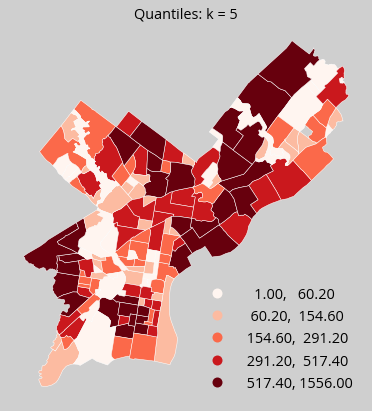

```python
# Quantiles Scheme
fig, ax = plt.subplots(figsize=(10, 7), facecolor="#cfcfcf")

totals.plot(
    ax=ax,
    column="size",
    edgecolor="white",
    linewidth=0.5,
    legend=True,
    legend_kwds=dict(loc="lower right"),
    cmap="Reds",
    scheme="Quantiles",
    k=5,
)
ax.set_title("Quantiles: k = 5")
ax.set_axis_off()
ax.set_aspect("equal")
```

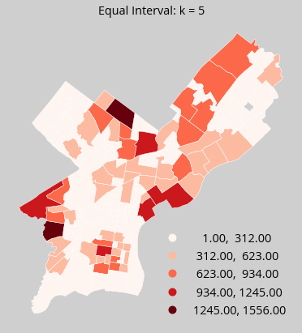

```python
## Equal Interval Scheme
fig, ax = plt.subplots(figsize=(10,7), facecolor='#cfcfcf')
totals.plot(
    ax=ax,
    column="size",
    edgecolor="white",
    linewidth=0.5,
    legend=True,
    legend_kwds=dict(loc='lower right'),
    cmap="Reds",
    scheme="EqualInterval",
    k=5
)
ax.set_title("Equal Interval: k = 5")
ax.set_axis_off()
ax.set_aspect("equal")
```

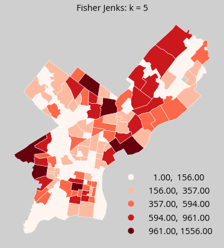

```python
## Fisher Jenks Scheme
fig, ax = plt.subplots(figsize=(10,7), facecolor='#cfcfcf')
totals.plot(
    ax=ax,
    column="size",
    edgecolor="white",
    linewidth=0.5,
    legend=True,
    legend_kwds=dict(loc='lower right'),
    cmap="Reds",
    scheme="FisherJenks",

)
ax.set_title("Fisher Jenks: k = 5")
ax.set_axis_off()
ax.set_aspect("equal")
```

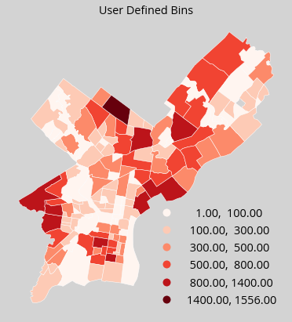

```python
## User Defined Scheme
fig, ax = plt.subplots(figsize=(10,7), facecolor='lightgray')
totals.plot(
    ax=ax,
    column="size",
    edgecolor="white",
    linewidth=0.5,
    legend=True,
    legend_kwds=dict(loc='lower right'),
    cmap="Reds",
    scheme="UserDefined",
    classification_kwds=dict(bins=[100, 300, 500, 800, 1400]) ## NEW: specify user defined bins
)
ax.set_title("User Defined Bins")
ax.set_axis_off()
ax.set_aspect("equal")
```

## Documentation for classification schemes

The documentation can be found here: https://pysal.org/mapclassify/api.html

Contains the full list of schemes and the function definitions for each.

## Neighborhood sizes still make it hard to compare raw counts

Better to normalize by area: **use the .area attribute of the geometry series**

```python
totals['N_per_area'] = totals['size'] / (totals.geometry.area)
```

Now plot the normalized totals:

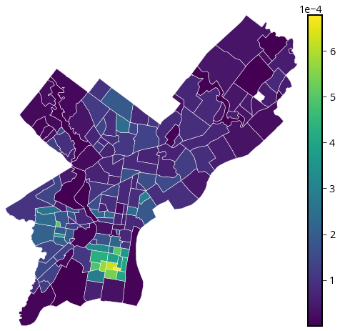

```python
# Create the figure
fig, ax = plt.subplots(figsize=(8, 8))

# NEW: Create a nice, lined up colorbar axes (called "cax" here)
divider = make_axes_locatable(ax)
cax = divider.append_axes("right", size="5%", pad=0.2)

# Plot
totals.plot(
    ax=ax,
    cax=cax,
    column="N_per_area",
    edgecolor="white",
    linewidth=0.5,
    legend=True,
    cmap="viridis",
)

# NEW: Get the limits of the GeoDataFrame
xmin, ymin, xmax, ymax = totals.total_bounds

# NEW: Set the xlims and ylims
ax.set_xlim(xmin, xmax)
ax.set_ylim(ymin, ymax)

# Format
ax.set_axis_off()
ax.set_aspect("equal")
```

### Even smarter

Since households are driving the 311 requests, it would be even better to normalize by the number of properties in a given neighborhood rather than neighborhood area

## More advanced: hex bins

Hexagonal bins aggregate quantities over small spatial regions.

**Use matplotlib's `hexbin()` function**

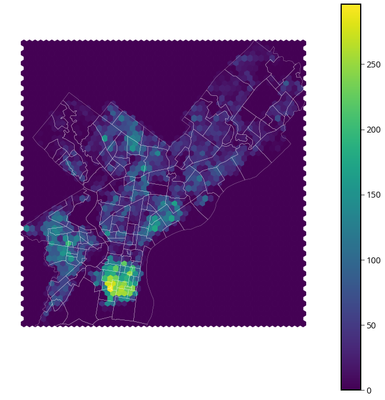

```python
# create the axes
fig, ax = plt.subplots(figsize=(12, 12))


# Extract out the x/y coordindates of the Point objects
xcoords = trash_requests.geometry.x
ycoords = trash_requests.geometry.y

# Plot a hexbin chart
hex_vals = ax.hexbin(xcoords, ycoords, gridsize=50)

# Add the zillow geometry boundaries
zillow.plot(ax=ax, facecolor="none", edgecolor="white", linewidth=0.25)


# add a colorbar and format
fig.colorbar(hex_vals, ax=ax)
ax.set_axis_off()
ax.set_aspect("equal")
```

## More advanced: adding a basemap

Let's plot a random sample of the requests, with a nice basemap underneath.

We'll use the [contextily](https://contextily.readthedocs.io/en/latest/intro_guide.html) utility package.

```python
import contextily as ctx
```

```python
# load the city limits data
city_limits = gpd.read_file('./data/City_Limits')
```

[figure not shown]

```python
# create the axes
fig, ax = plt.subplots(figsize=(12, 12))

# Plot a random sample of 1,000 requests as points
random_requests = trash_requests.sample(1000)

# Plot
random_requests.plot(ax=ax, marker='.', color='crimson')

# Add the city limits
city_limits.to_crs(trash_requests.crs).plot(ax=ax, edgecolor='black', linewidth=3, facecolor='none')

# NEW: plot the basemap underneath
ctx.add_basemap(ax=ax, crs=trash_requests.crs, source=ctx.providers.CartoDB.Positron)

# remove axis lines
ax.set_axis_off()
```

Lots of different tile providers available..

Easiest to use tab complete on `ctx.providers`

```python
ctx.providers
```

[output not shown]

[output cut: 1077 more lines]

[output not shown]

### Let's try the "Dark Matter" theme...

[figure not shown]

```python
# create the axes
fig, ax = plt.subplots(figsize=(12, 12))

# plot a random sample of requests
trash_requests.sample(1000).plot(ax=ax, marker='.', color='crimson')

# add the city limits
city_limits.to_crs(trash_requests.crs).plot(ax=ax, edgecolor='white', linewidth=3, facecolor='none')

# plot the basemap underneath
ctx.add_basemap(ax=ax, crs=trash_requests.crs, source=ctx.providers.CartoDB.DarkMatter) # NEW: DarkMatter

# remove axis lines
ax.set_axis_off()
```

## Can we do better?

Yes! Let's add interactivity. We'll start with `altair`...

Altair recently add full support for `GeoDataFrames`, making interactive choropleths very easy to make!

```python
import altair as alt
```

```python
# IMPORTANT: Altair needs the GeoDataFrame to be in EPSG:4326
totals_4326 = totals.to_crs(epsg=4326)

# plot map, where variables ares nested within `properties`,
(
    alt.Chart(totals_4326)
        .mark_geoshape(stroke="white")
        .encode(
            tooltip=["N_per_area:Q", "ZillowName:N", "size:Q"],
            color=alt.Color("N_per_area:Q", scale=alt.Scale(scheme="viridis")),
        ).properties(width=500, height=400)
)
```

[interactive chart not shown]

**Challenge for later:** use altair's *repeated charts* to show several choropleths for different 311 request types at once.

A similar example (using a different dataset) is available in the [altair gallery](https://altair-viz.github.io/gallery/choropleth_repeat.html).

## Exercise: property assessments in Philadelphia

**Goals**: Visualize the property assessment values by neighborhood in Philadelphia, using a

1. static choropleth map
2. hex bin map
3. interactive choropleth with altair

**Challenge (if time remaining)**: Visualize the highest-valued residential and commercial properties as points on top of a `contextily` basemap

## Dataset

2019 property assessment data:

- from [OpenDataPhilly](https://www.opendataphilly.org/dataset/opa-property-assessments)
- residential properties only — over 460,000 properties

## Step 1: Load the assessment data

```python
data = pd.read_csv('./data/opa_residential.csv')
data.head()
```

|  | parcel_number | lat | lng | location | market_value | building_value | land_value | total_land_area | total_livable_area |
| --- | --- | --- | --- | --- | --- | --- | --- | --- | --- |
| 0 | 71361800 | 39.991575 | -75.128994 | 2726 A ST | 62200.0 | 44473.0 | 17727.0 | 1109.69 | 1638.0 |
| 1 | 71362100 | 39.991702 | -75.128978 | 2732 A ST | 25200.0 | 18018.0 | 7182.0 | 1109.69 | 1638.0 |
| 2 | 71362200 | 39.991744 | -75.128971 | 2734 A ST | 62200.0 | 44473.0 | 17727.0 | 1109.69 | 1638.0 |
| 3 | 71362600 | 39.991994 | -75.128895 | 2742 A ST | 15500.0 | 11083.0 | 4417.0 | 1109.69 | 1638.0 |
| 4 | 71363800 | 39.992592 | -75.128743 | 2814 A ST | 31300.0 | 22400.0 | 8900.0 | 643.50 | 890.0 |

We'll focus on the `market_value` column for this analysis

## Step 2: Convert to a GeoDataFrame

Remember to set the EPSG of the input data — this data is in the typical lat/lng coordinates (EPSG=4326)

## Step 3: Do a spatial join with Zillow neighbohoods

Use the `sjoin()` function.

Make sure you CRS's match before doing the sjoin!

## Step 4: Make a choropleth of the median market value by neighborhood

Hints:

- You will need to group by Zillow neighborhood
- Calculate the median market value per neighborhood
- Join with the Zillow neighborhood GeoDataFrame

## Step 5: Make a hex bin map of median assessments

Hints:

- You will need to use the `C` and `reduce_C_function` of the `hexbin()` function
- Run `plt.hexbin?` for more help
- Try testing the impact of setting `bins='log'` on the resulting map

**Note:** you should pass in the raw point data rather than any aggregated data to the `hexbin()` function

## Step 6: Use altair to make an interactive choropleth

## Challenge: Properties with the highest assessed values

- Can you make a plot of the top 20 properties by market value?
- Try adding in a basemap underneath the plot

*They are all located in Center City*

### Let's zoom in on Center City

**Hint:** You can use the `total_bounds` of the top 20 properties dataframe to get the x/y limits of the axes

### Note

The axes limits must be set **before** the call to the `ctx.add_basemap()`. This enables contextily to load a basemap with the proper level of zoom!

## That's it!

- More interactive viz libraries and raster datasets next week!
- See you next Monday!